# Comparing Classifiers on Online Shopper Purchase Intent

DA5030

Kelsey Brown

2026-08-01

## Introduction

In this report I will be using the Online Shoppers Purchasing Intention Dataset from the UCI Machine Learning Repository. It contains one row per browsing session on an e-commerce site over a one-year period, with 10 numeric features (page counts and durations, bounce rate, exit rate, page value, special-day proximity) and 7 categorical/ordinal features (month, operating system, browser, region, traffic type, visitor type, weekend flag).

My target is Revenue, a binary True/False flag for whether the session ended in a purchase. I will be comparing three different classifiers on this same target to see which approach handles the problem best: logistic regression, decision tree, kNN (k-nearest neighbor) and then one combined heterogeneous model with them all. This keeps the project focused on a single business question (“will this session convert?”) and allows a direct, apples-to-apples performance comparison across algorithms.

I am using these three algorithms because logistic regression gives interpretable coefficients/odds ratios a business stakeholder can act on directly (e.g., “each additional page view increases purchase odds by X%”), decision trees produce visualizable if-then rules that are the most explainable to a non-technical audience, and kNN tests whether a purely instance-based, non-parametric approach can compete once features are scaled.

Prior work includes Sakar et al. (2018/2019), who used this data to build MLP classifiers, benchmarked against SVM and random forest, optimizing for maximum predictive accuracy. Additionally, in 2026, Yin and Li used this data to compare SVM, decision trees, and logistic regression prediction. My project differs in emphasis from both of these because while I am also using logistic regression and decision trees, with the addition of kNN I’m using simpler, more interpretable models rather than neural nets, prioritizing business legibility and a direct comparison of “classic” algorithms to also get a sense of those algorithms strengths and weaknesses. I will also employ a heterogeneous model to see the efficacy of that.

My research question is: Can browsing behavior captured during a single e-commerce session (page views, durations, bounce/exit rates, and visitor context) predict whether that session will end in a purchase, and which of three classic classification approaches, logistic regression, decision tree, kNN, or a heterogenous ensemble of all three, best identifies purchase intent given a potential class imbalance?

My evaluation methods will be: accuracy, precision, recall, F1, and AUC across all three models, compared side by side. Accuracy alone would be misleading if there is a class imbalance, so if that is the case, F1 and AUC will carry more weight in my conclusions.

### Expectations going in

If there is a class imbalance, it will dominate the results. If there is a class imbalance, I expect F1 and AUC to tell a very different, more honest story than accuracy alone, and I expect this imbalance to affect each algorithm differently: logistic regression and decision trees can often be adjusted for imbalance fairly directly (class weights, threshold tuning), while kNN is more sensitive to imbalance by construction, since majority-class neighbors can simply outvote minority-class ones regardless of true proximity.

PageValues will be the strongest single predictor. Based on general e-commerce intuition (and consistent with what Sakar et al. found), I expect PageValues, a metric tied to pages associated with revenue-generating actions, to carry disproportionate predictive weight across all three models, potentially to the point of overshadowing other features.

The numeric features will be right-skewed and will need transformation. Duration and rate-based columns (BounceRates, ExitRates, the _Duration fields) typically show this pattern in web analytics data, since most sessions are short and low-engagement, with a right-skewed tail of highly engaged sessions. I expect this to matter more for kNN (distance-based, sensitive to scale and outliers) than for the decision tree (distribution-agnostic), with logistic regression somewhere in between.

Some numeric features are likely correlated with each other. I expect the page-count and page-duration pairs (e.g., ProductRelated and ProductRelated_Duration) to be meaningfully correlated, since more pages viewed and more time spent tend to move together. I plan to confirm this in EDA and decide whether that redundancy needs to be addressed or simply accepted depending on the model.

The heterogeneous ensemble will outperform any single model, but probably not dramatically. Combining models with different strengths and blind spots typically smooths out individual weaknesses, but I don’t expect a dramatic jump, more a modest, more stable improvement, particularly in recall for the minority class (if imbalanced), which is where I would guess the individual models struggle most.

## Data Loading and Understanding

In this section, I will load the packages required and the data. I will then conduct an Exploratory Data Analysis (EDA) to get a sense of my variables, their distributions, and thr transformations that need to take place.

### Loading

[output not shown]

```r
#Downloading
download.file("https://archive.ics.uci.edu/static/public/468/online+shoppers+purchasing+intention+dataset.zip",
              "online-shoppers.csv.zip")

#Unzipping
unzip("online-shoppers.csv.zip")

df <- read.csv("online_shoppers_intention.csv",
                header = TRUE, stringsAsFactors = TRUE)
```

### EDA

In this subsection, I will conduct an Exploratory Data Analysis to make the decisions that will be carried out in the Data and Preparation section.

#### Basic Structure

```r
str(df)
```

```
## 'data.frame':    12330 obs. of  18 variables:
##  $ Administrative         : int  0 0 0 0 0 0 0 1 0 0 ...
##  $ Administrative_Duration: num  0 0 0 0 0 0 0 0 0 0 ...
##  $ Informational          : int  0 0 0 0 0 0 0 0 0 0 ...
##  $ Informational_Duration : num  0 0 0 0 0 0 0 0 0 0 ...
##  $ ProductRelated         : int  1 2 1 2 10 19 1 0 2 3 ...
##  $ ProductRelated_Duration: num  0 64 0 2.67 627.5 ...
##  $ BounceRates            : num  0.2 0 0.2 0.05 0.02 ...
##  $ ExitRates              : num  0.2 0.1 0.2 0.14 0.05 ...
##  $ PageValues             : num  0 0 0 0 0 0 0 0 0 0 ...
##  $ SpecialDay             : num  0 0 0 0 0 0 0.4 0 0.8 0.4 ...
##  $ Month                  : Factor w/ 10 levels "Aug","Dec","Feb",..: 3 3 3 3 3 3 3 3 3 3 ...
##  $ OperatingSystems       : int  1 2 4 3 3 2 2 1 2 2 ...
##  $ Browser                : int  1 2 1 2 3 2 4 2 2 4 ...
##  $ Region                 : int  1 1 9 2 1 1 3 1 2 1 ...
##  $ TrafficType            : int  1 2 3 4 4 3 3 5 3 2 ...
##  $ VisitorType            : Factor w/ 3 levels "New_Visitor",..: 3 3 3 3 3 3 3 3 3 3 ...
##  $ Weekend                : logi  FALSE FALSE FALSE FALSE TRUE FALSE ...
##  $ Revenue                : logi  FALSE FALSE FALSE FALSE FALSE FALSE ...
```

```r
summary(df)
```

```
##  Administrative   Administrative_Duration Informational
##  Min.   : 0.000   Min.   :   0.00         Min.   : 0.0000
##  1st Qu.: 0.000   1st Qu.:   0.00         1st Qu.: 0.0000
##  Median : 1.000   Median :   7.50         Median : 0.0000
##  Mean   : 2.315   Mean   :  80.82         Mean   : 0.5036
##  3rd Qu.: 4.000   3rd Qu.:  93.26         3rd Qu.: 0.0000
##  Max.   :27.000   Max.   :3398.75         Max.   :24.0000
##
##  Informational_Duration ProductRelated   ProductRelated_Duration
##  Min.   :   0.00        Min.   :  0.00   Min.   :    0.0
##  1st Qu.:   0.00        1st Qu.:  7.00   1st Qu.:  184.1
##  Median :   0.00        Median : 18.00   Median :  598.9
##  Mean   :  34.47        Mean   : 31.73   Mean   : 1194.7
##  3rd Qu.:   0.00        3rd Qu.: 38.00   3rd Qu.: 1464.2
##  Max.   :2549.38        Max.   :705.00   Max.   :63973.5
##
##   BounceRates         ExitRates         PageValues        SpecialDay
##  Min.   :0.000000   Min.   :0.00000   Min.   :  0.000   Min.   :0.00000
##  1st Qu.:0.000000   1st Qu.:0.01429   1st Qu.:  0.000   1st Qu.:0.00000
##  Median :0.003112   Median :0.02516   Median :  0.000   Median :0.00000
##  Mean   :0.022191   Mean   :0.04307   Mean   :  5.889   Mean   :0.06143
##  3rd Qu.:0.016813   3rd Qu.:0.05000   3rd Qu.:  0.000   3rd Qu.:0.00000
##  Max.   :0.200000   Max.   :0.20000   Max.   :361.764   Max.   :1.00000
##
##      Month      OperatingSystems    Browser           Region
##  May    :3364   Min.   :1.000    Min.   : 1.000   Min.   :1.000
##  Nov    :2998   1st Qu.:2.000    1st Qu.: 2.000   1st Qu.:1.000
##  Mar    :1907   Median :2.000    Median : 2.000   Median :3.000
##  Dec    :1727   Mean   :2.124    Mean   : 2.357   Mean   :3.147
##  Oct    : 549   3rd Qu.:3.000    3rd Qu.: 2.000   3rd Qu.:4.000
##  Sep    : 448   Max.   :8.000    Max.   :13.000   Max.   :9.000
##  (Other):1337
##   TrafficType               VisitorType     Weekend         Revenue
##  Min.   : 1.00   New_Visitor      : 1694   Mode :logical   Mode :logical
##  1st Qu.: 2.00   Other            :   85   FALSE:9462      FALSE:10422
##  Median : 2.00   Returning_Visitor:10551   TRUE :2868      TRUE :1908
##  Mean   : 4.07
##  3rd Qu.: 4.00
##  Max.   :20.00
##
```

```r
colnames(df)
```

```
##  [1] "Administrative"          "Administrative_Duration"
##  [3] "Informational"           "Informational_Duration"
##  [5] "ProductRelated"          "ProductRelated_Duration"
##  [7] "BounceRates"             "ExitRates"
##  [9] "PageValues"              "SpecialDay"
## [11] "Month"                   "OperatingSystems"
## [13] "Browser"                 "Region"
## [15] "TrafficType"             "VisitorType"
## [17] "Weekend"                 "Revenue"
```

```r
head(df)
```

```
##   Administrative Administrative_Duration Informational Informational_Duration
## 1              0                       0             0                      0
## 2              0                       0             0                      0
## 3              0                       0             0                      0
## 4              0                       0             0                      0
## 5              0                       0             0                      0
## 6              0                       0             0                      0
##   ProductRelated ProductRelated_Duration BounceRates ExitRates PageValues
## 1              1                0.000000  0.20000000 0.2000000          0
## 2              2               64.000000  0.00000000 0.1000000          0
## 3              1                0.000000  0.20000000 0.2000000          0
## 4              2                2.666667  0.05000000 0.1400000          0
## 5             10              627.500000  0.02000000 0.0500000          0
## 6             19              154.216667  0.01578947 0.0245614          0
##   SpecialDay Month OperatingSystems Browser Region TrafficType
## 1          0   Feb                1       1      1           1
## 2          0   Feb                2       2      1           2
## 3          0   Feb                4       1      9           3
## 4          0   Feb                3       2      2           4
## 5          0   Feb                3       3      1           4
## 6          0   Feb                2       2      1           3
##         VisitorType Weekend Revenue
## 1 Returning_Visitor   FALSE   FALSE
## 2 Returning_Visitor   FALSE   FALSE
## 3 Returning_Visitor   FALSE   FALSE
## 4 Returning_Visitor   FALSE   FALSE
## 5 Returning_Visitor    TRUE   FALSE
## 6 Returning_Visitor   FALSE   FALSE
```

This dataset has 18 columns with 12330 observations.

Revenue (TRUE/FALSE) is the target variable.

As noted, there are 10 numeric/continuous features (Administrative, Administrative_Duration, Informational, Informational_Duration, ProductRelated, ProductRelated_Duration, BounceRates, ExitRates, PageValues, SpecialDay), and 8 categorical or ordinal features (Month, OperatingSystems, Browser, Region, TrafficType, VisitorType, Weekend, and the target Revenue).

A few observations are:

1.) This output shows that there is a class imbalance. Revenue splits into 10422 FALSE / 1908 TRUE, which works out to ~ 15.5% positive. This will be addressed in the data shaping section.

3.) VisitorType is dominated by returning visitors. 10551 of 12330 sessions are Returning_Visitor, which will matter for how much signal that feature actually carries relative to its imbalance, and is worth keeping in mind if it turns out to be a strong predictor

4.) Structure confirms mostly clean typing, with a few decisions still needed. Numeric fields are read in as int/num appropriately, Weekend and Revenue as logical (will need to be dummy encoded for logistic regression and kNN), and Month and VisitorType are already factors. However, OperatingSystems, Browser, Region, and TrafficType are still stored as raw integers even though they’re categorical/nominal codes. These need explicit factor conversion in cleaning so they’re not mistakenly treated as continuous by logistic regression or kNN.

#### Target Variable Exploration

Now, I will take a look at the target variable. I will get a sense again of it’s classes and plot their distribution to confirm the class imbalance and to make sure there are no other levels.

```r
#Getting class counts
table(df$Revenue)
```

```
##
## FALSE  TRUE
## 10422  1908
```

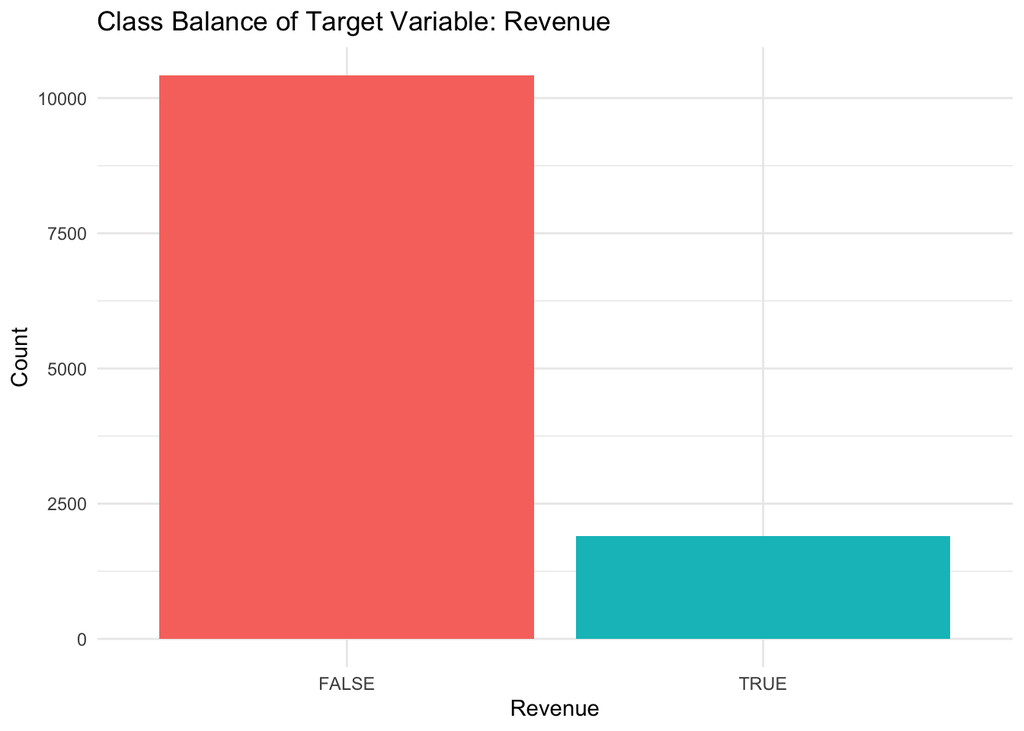

```r
#Plotting
ggplot(df, aes(x = Revenue, fill = Revenue)) +
  geom_bar() +
  labs(title = "Class Balance of Target Variable: Revenue",
       x = "Revenue",
       y = "Count") +
  theme_minimal() +
  theme(legend.position = "none")
```

This confirms and visualizes the class imbalance. This means that models trained on the data as-is will tend to be biased toward predicting the majority class (no purchase), which can produce misleadingly high accuracy while performing poorly on the outcome that actually matters for the business question, identifying sessions likely to convert. This affects the three algorithms to different degrees: kNN is particularly sensitive, since majority-class neighbors can simply outvote minority-class ones regardless of true proximity; logistic regression will tend to fit coefficients that favor predicting the majority class unless corrected; and decision trees are somewhat more robust by construction but not immune, since default splitting criteria still favor the majority class.

To address this, I will apply random undersampling of the majority class when training the logistic regression and kNN models, bringing the class ratio closer to balanced. I considered this against oversampling and SMOTE; I chose undersampling primarily for simplicity and because the dataset is large enough that losing majority-class rows still leaves a workable training set. For the decision tree, I will instead address class imbalance using case weights, up-weighting the minority (purchase) class during training so it isn’t overwhelmed by the majority class, without discarding any rows. I initially considered a cost matrix, which C5.0 supports natively and which would let me assign an explicit business-interpretable cost ratio to false negatives (missed purchasers) versus false positives. However, C5.0 does not produce valid class probabilities when a cost matrix is applied, which would have prevented me from computing AUC for the tree and broken the consistency of my cross-model evaluation. Case weights avoid this issue, remain compatible with boosting, and keep AUC available across all three models, so I chose weights over a cost matrix for this reason.

#### NA and Zero Check

Though I did not see any NAs in the Basic Structure subsection, I will now explicitly check for NA values.

```r
colSums(is.na(df))
```

```
##          Administrative Administrative_Duration           Informational
##                       0                       0                       0
##  Informational_Duration          ProductRelated ProductRelated_Duration
##                       0                       0                       0
##             BounceRates               ExitRates              PageValues
##                       0                       0                       0
##              SpecialDay                   Month        OperatingSystems
##                       0                       0                       0
##                 Browser                  Region             TrafficType
##                       0                       0                       0
##             VisitorType                 Weekend                 Revenue
##                       0                       0                       0
```

This confirms that there are no NA values. Next, I will check the levels of the factor variables to visually scan for placeholders.

```r
levels(df$Month)
```

```
##  [1] "Aug"  "Dec"  "Feb"  "Jul"  "June" "Mar"  "May"  "Nov"  "Oct"  "Sep"
```

```r
levels(df$VisitorType)
```

```
## [1] "New_Visitor"       "Other"             "Returning_Visitor"
```

Though it is a documented category in the UCI data (on the site it does not say this column is missing any data), the “Other” category is something to interrogate.

```r
table(df$VisitorType)
```

```
##
##       New_Visitor             Other Returning_Visitor
##              1694                85             10551
```

Given how small this category is, I considered collapsing it into New_Visitor to simplify the feature, but decided against it: “Other” isn’t documented as a variant of “new visitor,” and merging the two would impute an identity for those 85 sessions that isn’t actually supported by the data. I also considered dropping these rows, but there’s no data quality issue here; the category is valid and legitimate, and removing good observations simply because a category is small and inconvenient isn’t a defensible reason to shrink the dataset.

Next, I will table the integer categories that are actually categorical data and will be transformed later to look for any placeholder or missing values.

```r
table(df$OperatingSystems)
```

```
##
##    1    2    3    4    5    6    7    8
## 2585 6601 2555  478    6   19    7   79
```

```r
table(df$Browser)
```

```
##
##    1    2    3    4    5    6    7    8    9   10   11   12   13
## 2462 7961  105  736  467  174   49  135    1  163    6   10   61
```

```r
table(df$Region)
```

```
##
##    1    2    3    4    5    6    7    8    9
## 4780 1136 2403 1182  318  805  761  434  511
```

```r
table(df$TrafficType)
```

```
##
##    1    2    3    4    5    6    7    8    9   10   11   12   13   14   15   16
## 2451 3913 2052 1069  260  444   40  343   42  450  247    1  738   13   38    3
##   17   18   19   20
##    1   10   17  198
```

All four variables show sequential, contiguous integer codes with no negative values and no suspicious outlier codes like -1 or 99 sitting apart from the rest.

One thing worth flagging for later: several of these codes have very low counts (e.g., Browser category 9 has only 1 observation, TrafficType category 12 has only 1, and a handful of others sit in the single digits). This isn’t a data quality issue, but it is a sparsity issue worth addressing before encoding: one-hot encoding these as-is would produce several columns with almost no positive cases, adding noise and unstable coefficients, particularly for logistic regression and kNN. I will group rare categories (below 1% of the entire category) into a single “Other” bucket for each of these four variables during feature engineering, applied before the train/test split, and used specifically for the logistic regression and kNN training sets. The decision tree will retain the original, ungrouped categories, since C5.0 splits directly on categorical levels without requiring one-hot encoding, so the sparse-column problem this grouping is meant to solve doesn’t apply to that model. I chose to do the grouping on the full dataset rather than separately per split to ensure category groupings stay consistent between training and test data, avoiding a situation where a rare category collapsed in training appears as an unseen level in the test set; since this only affects category definitions and not the target variable, the leakage risk is minimal.

Finally, I will interrogate the numeric paired variables (the _Duration variables), to make sure that a duration is never recorded for a page-type with zero visits (e.g., Administrative == 0 but Administrative_Duration > 0), since that combination would be logically inconsistent

```r
sum(df$Administrative == 0 & df$Administrative_Duration > 0)
```

```
## [1] 0
```

```r
sum(df$Informational == 0 & df$Informational_Duration > 0)
```

```
## [1] 0
```

```r
sum(df$ProductRelated == 0 & df$ProductRelated_Duration > 0)
```

```
## [1] 0
```

There are no illogical pairs in this dataset.

#### Numeric Variable Distributions

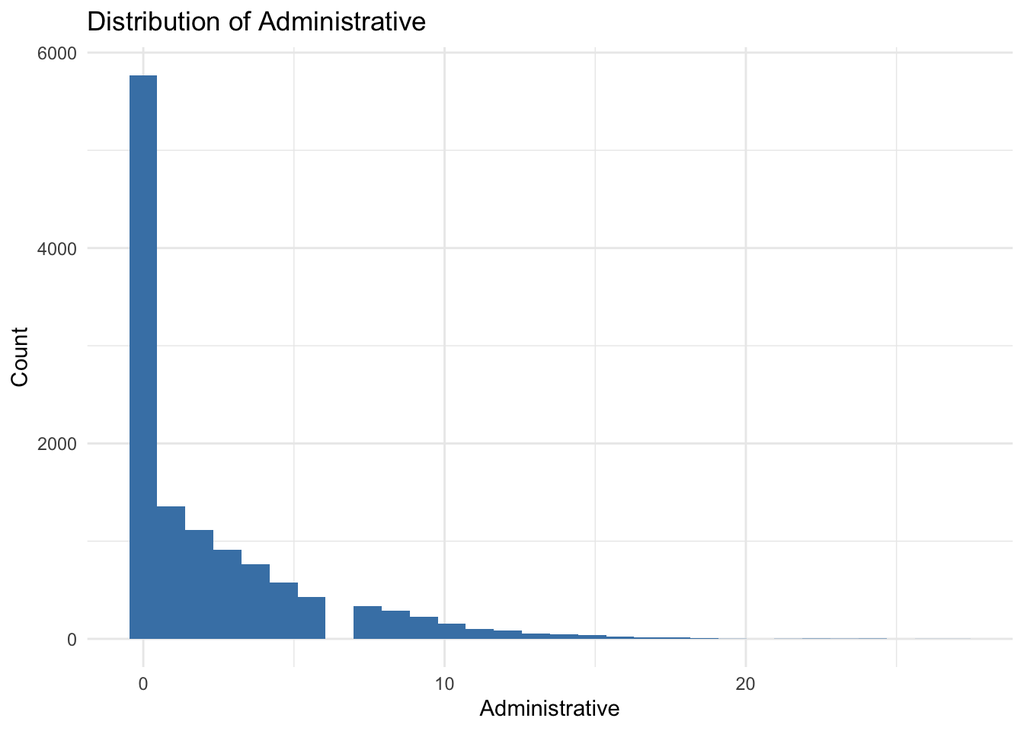

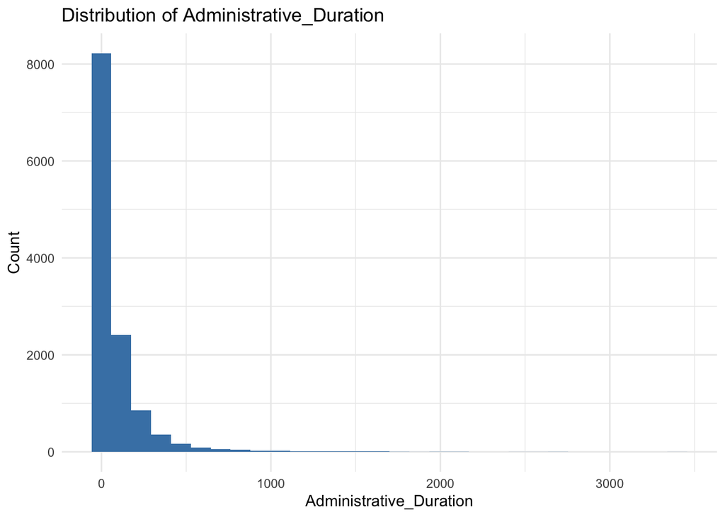

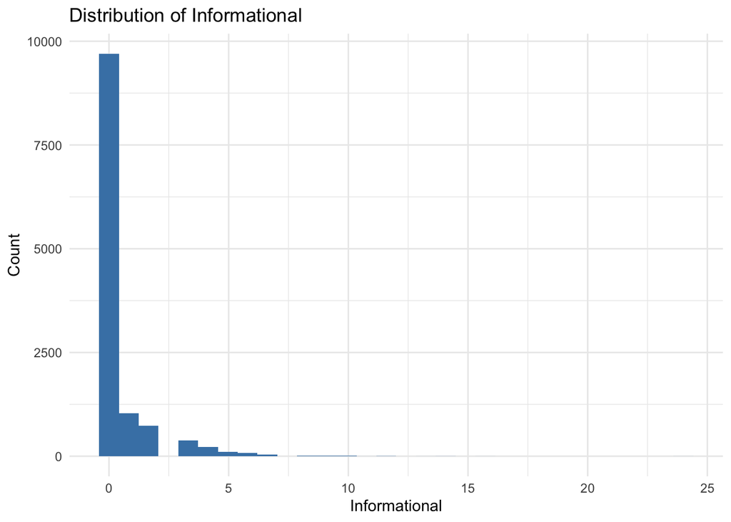

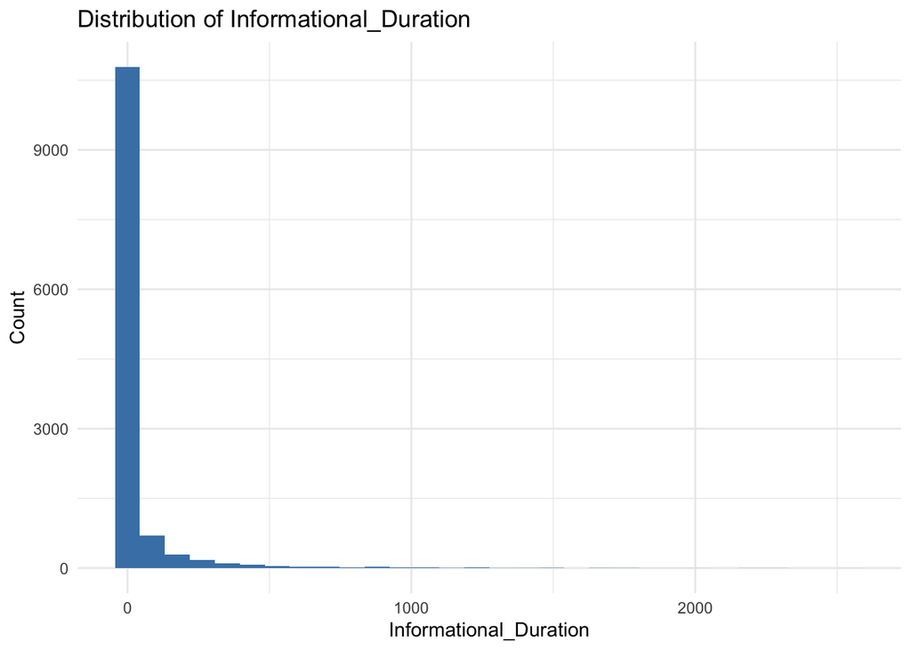

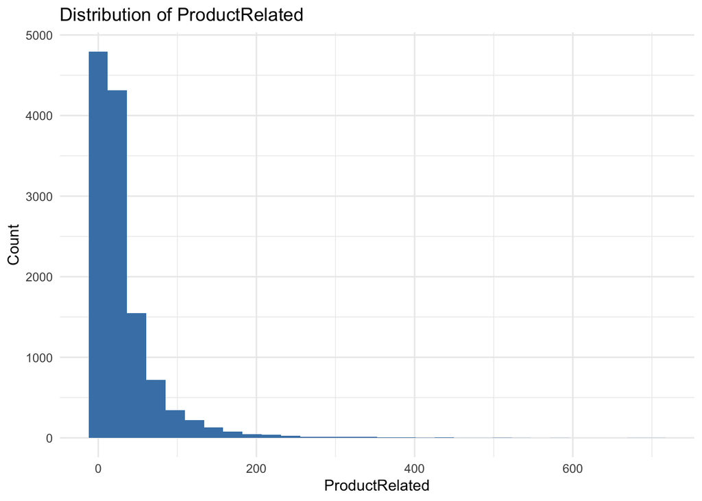

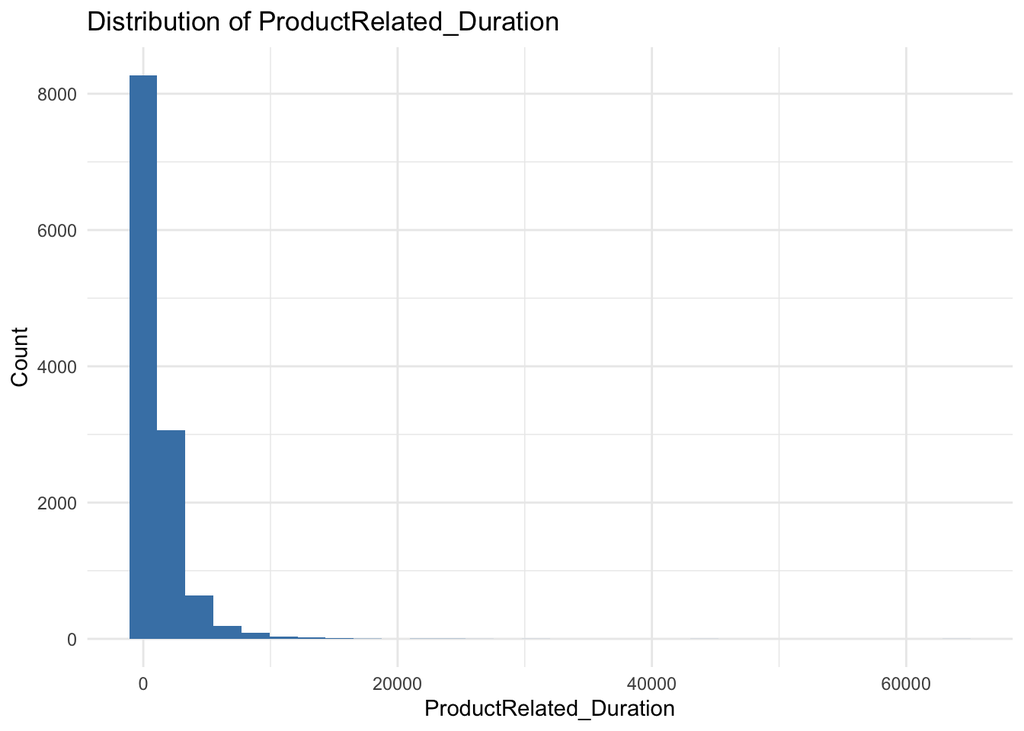

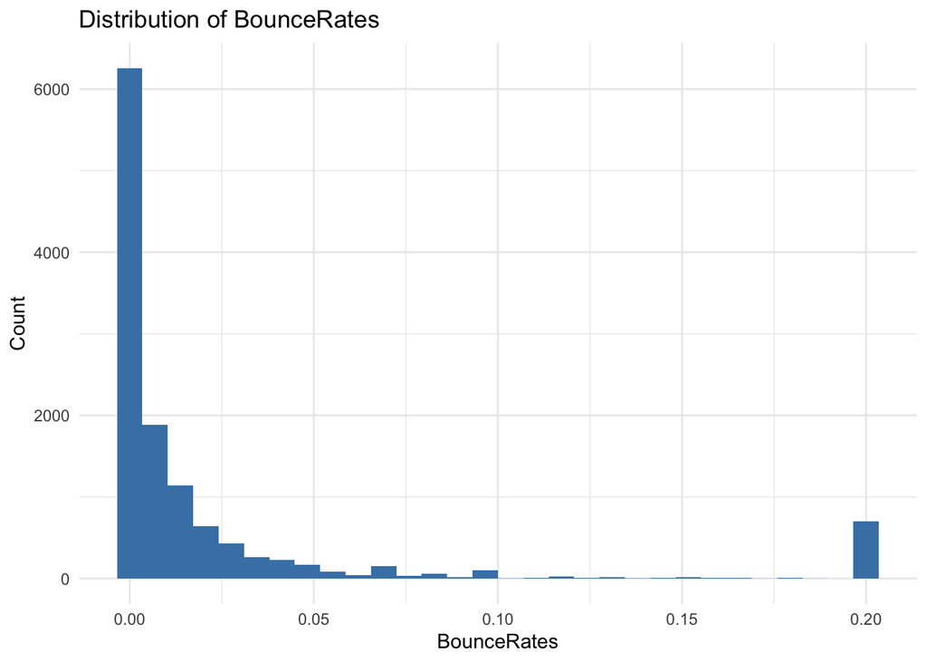

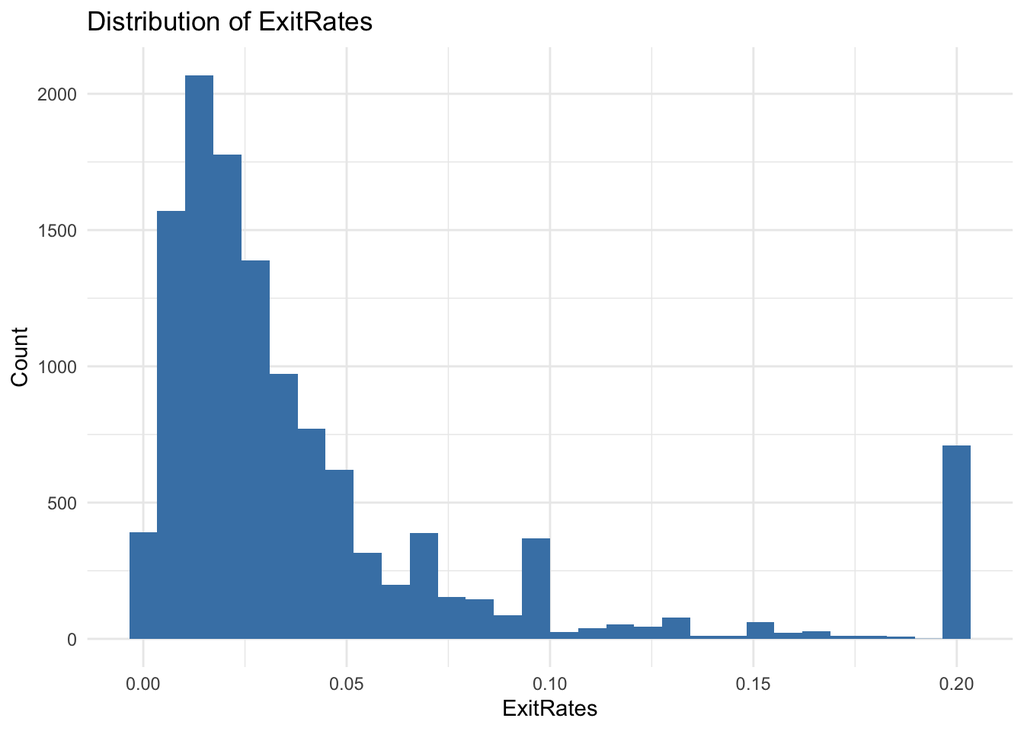

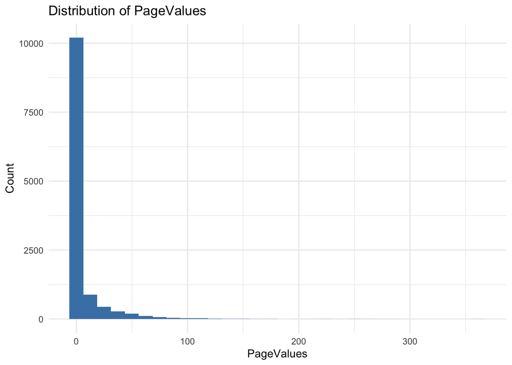

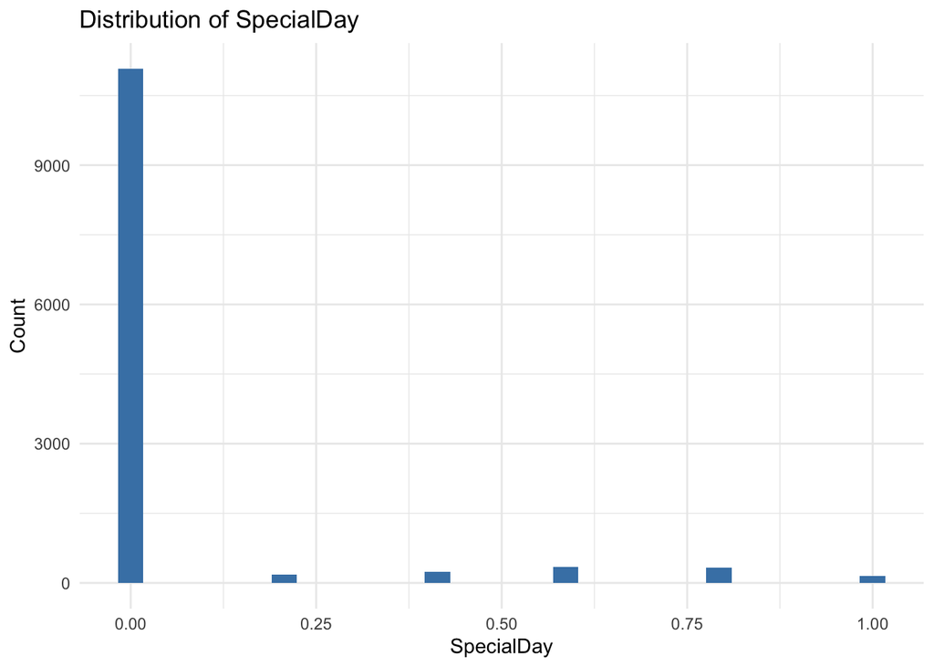

A few variables show something more specific worth flagging individually:

1.) SpecialDay is not truly continuous, as the UCI documentation suggests, and it only takes six discrete values (0, 0.2, 0.4, 0.6, 0.8, 1.0), visible as distinct bars rather than a smooth distribution. This is a proximity-to-holiday indicator rather than a measured continuous quantity, because 0 = not near a holiday, and 1 = on a holiday itself. I address the specific encoding decision (ordinal vs. nominal treatment) later based on its relationship with the target.

2.) ExitRates is the one variable that doesn’t follow the extreme zero-spike pattern, it’s still right-skewed, but its shape is closer to a moderate, single-peaked distribution centered around 0.02–0.03.

These skewed numeric variables (Administrative, Administrative_Duration, Informational, Informational_Duration, ProductRelated, ProductRelated_Duration, BounceRates, ExitRates, and PageValues) will need a transformation for both kNN and logistic regression. For both models, I will apply a log1p() transformation rather than plain log, since several of these variables contain true zeros that would otherwise produce undefined values). This compresses the long right tail and brings each variable closer to a usable, roughly symmetric shape without discarding any legitimate high-engagement sessions as outliers.

For kNN specifically, I will additionally z-score standardize the logged variables. This is a separate requirement because these variables currently range from roughly 0–0.2 (BounceRates) up to 0–64,000 (ProductRelated_Duration), and since kNN computes distance directly across features, an unscaled variable like ProductRelated_Duration would dominate every distance calculation and effectively drown out the other features. Standardizing after the log transform ensures each variable contributes comparably to distance, while the log step itself prevents any single extreme value from stretching that standardized distance.

For logistic regression, the log transform alone is sufficient, and I will not additionally z-score these variables for that model, since glm() doesn’t rely on distance.

I am not applying outlier removal to these variables prior to transformation. Z-score-based outlier detection assumes a roughly normal distribution, which is precisely what these variables lack in their raw form. Instead, I will detect and manage outliers after transformation.

#### Numeric Variable Relationships to Target

I will plot the numeric variables in relationship to the target to get a sense of which could be highly correlated with the target.

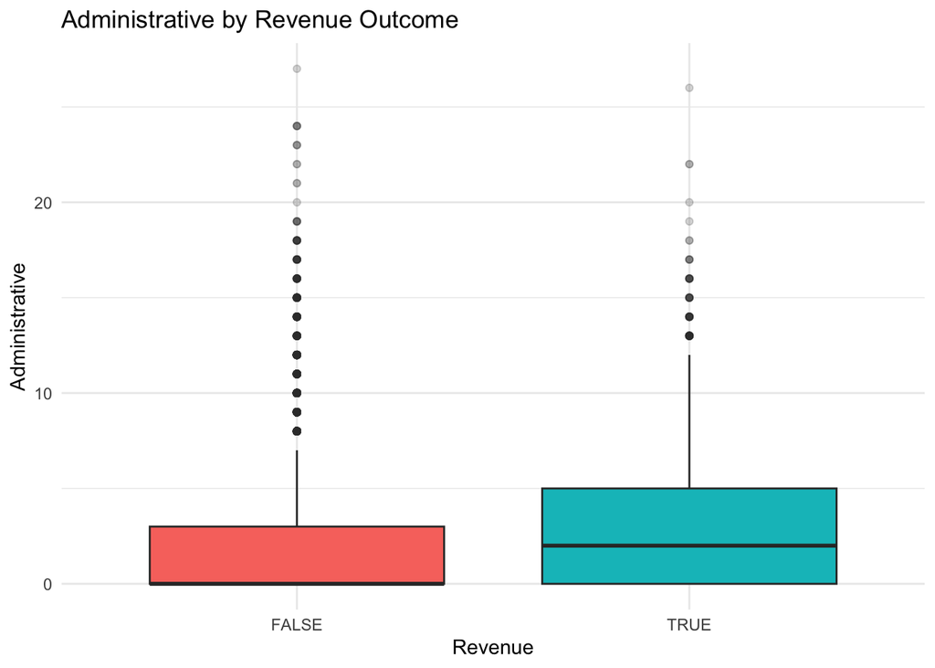

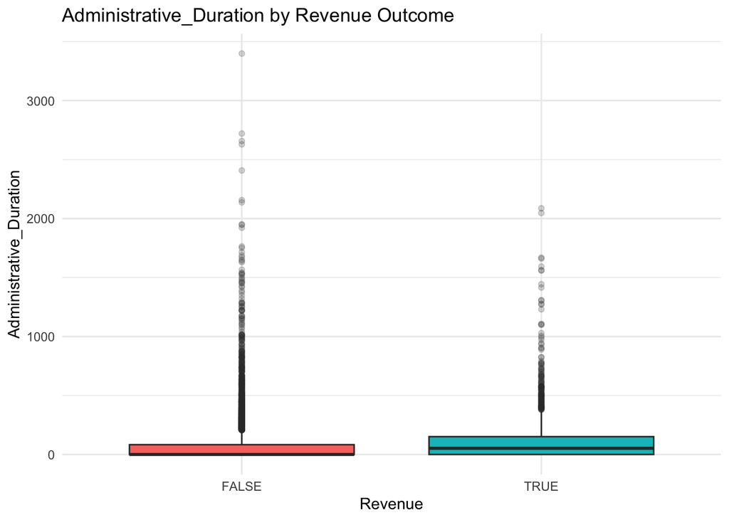

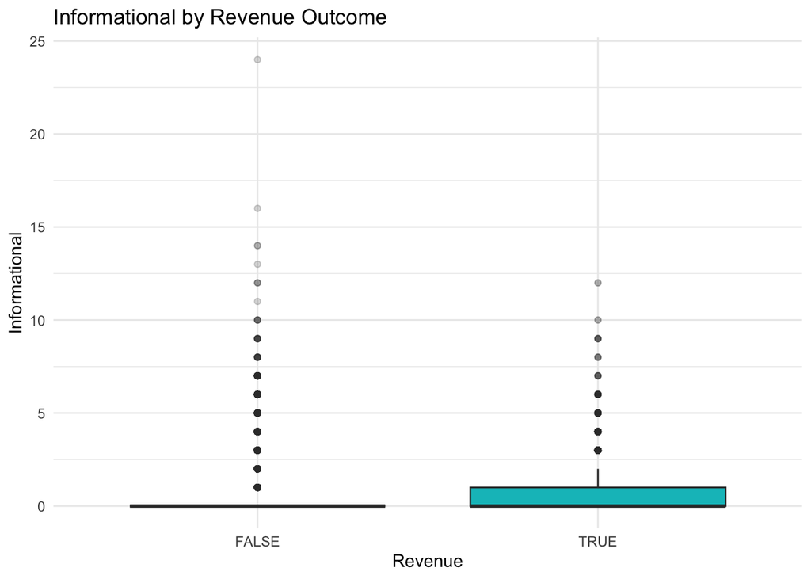

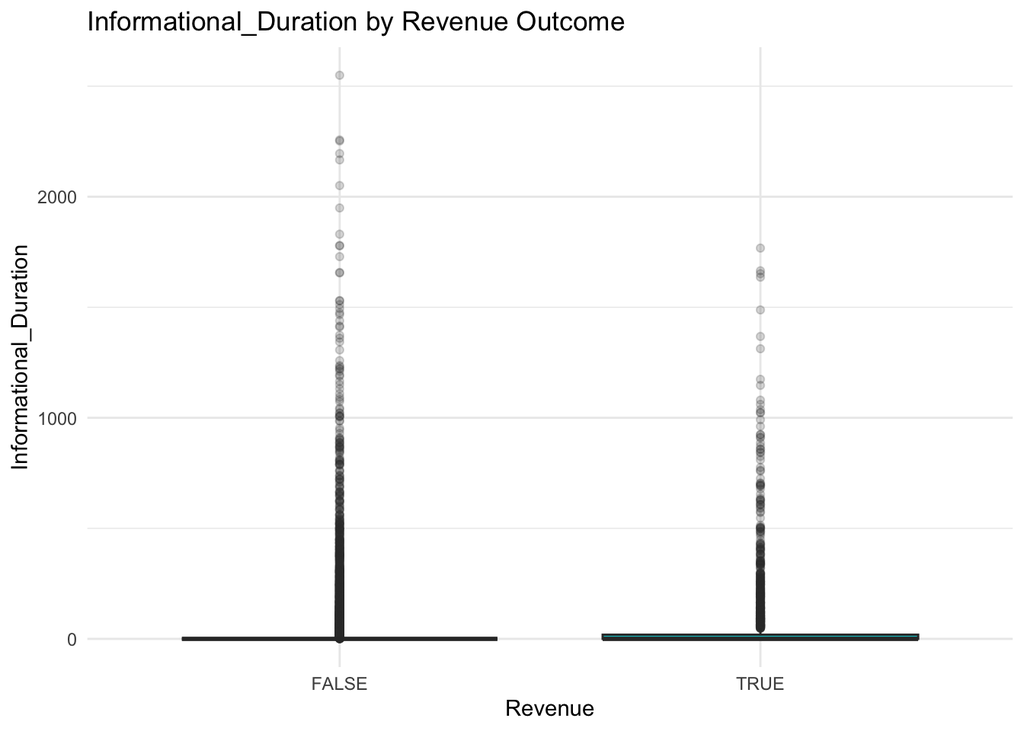

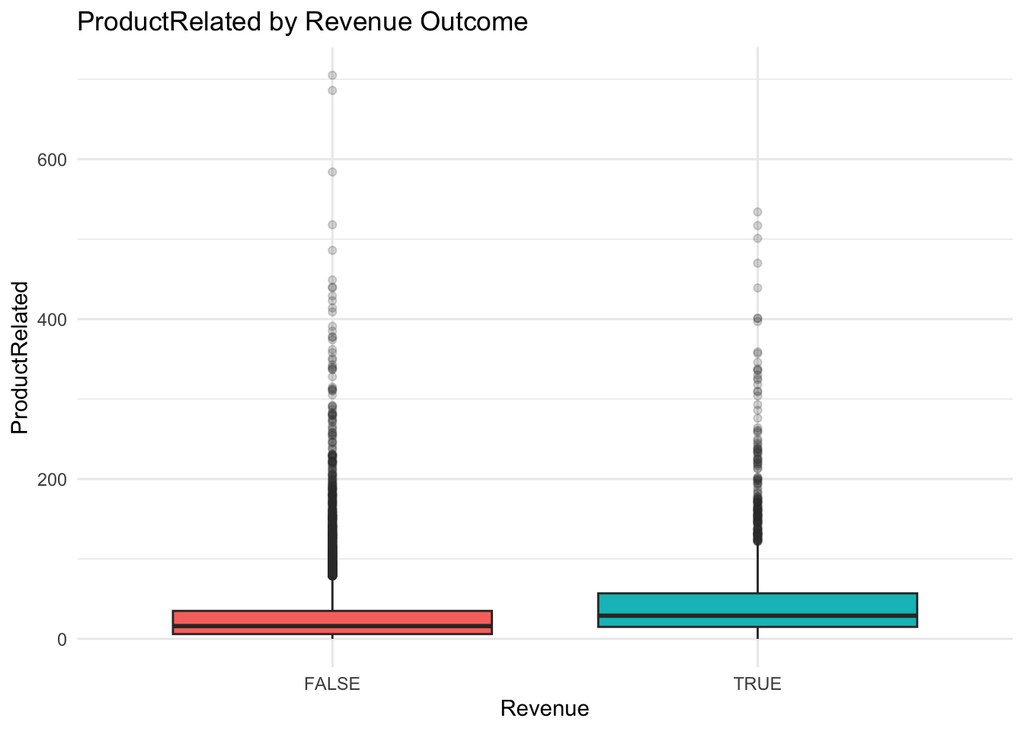

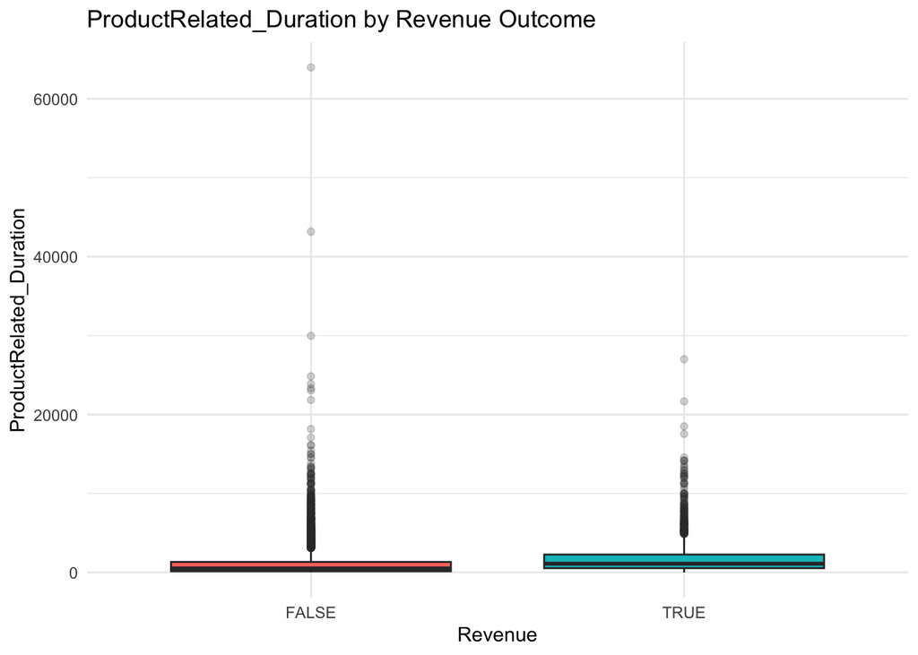

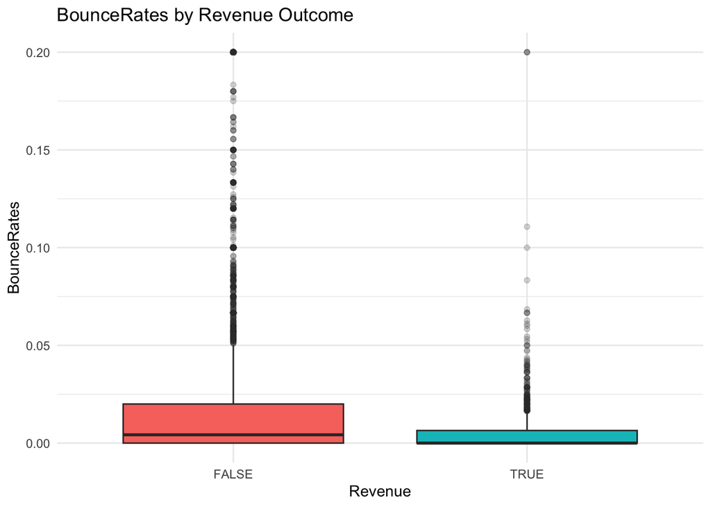

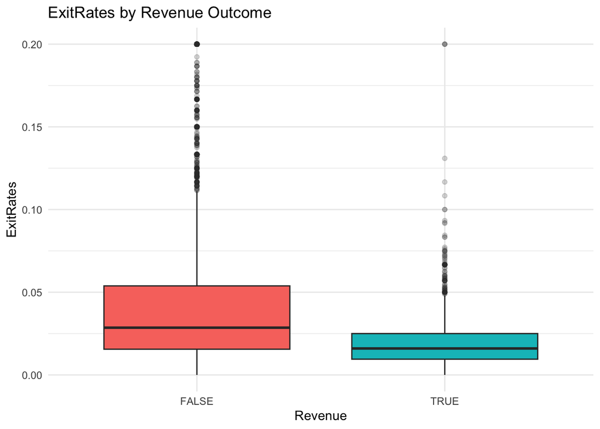

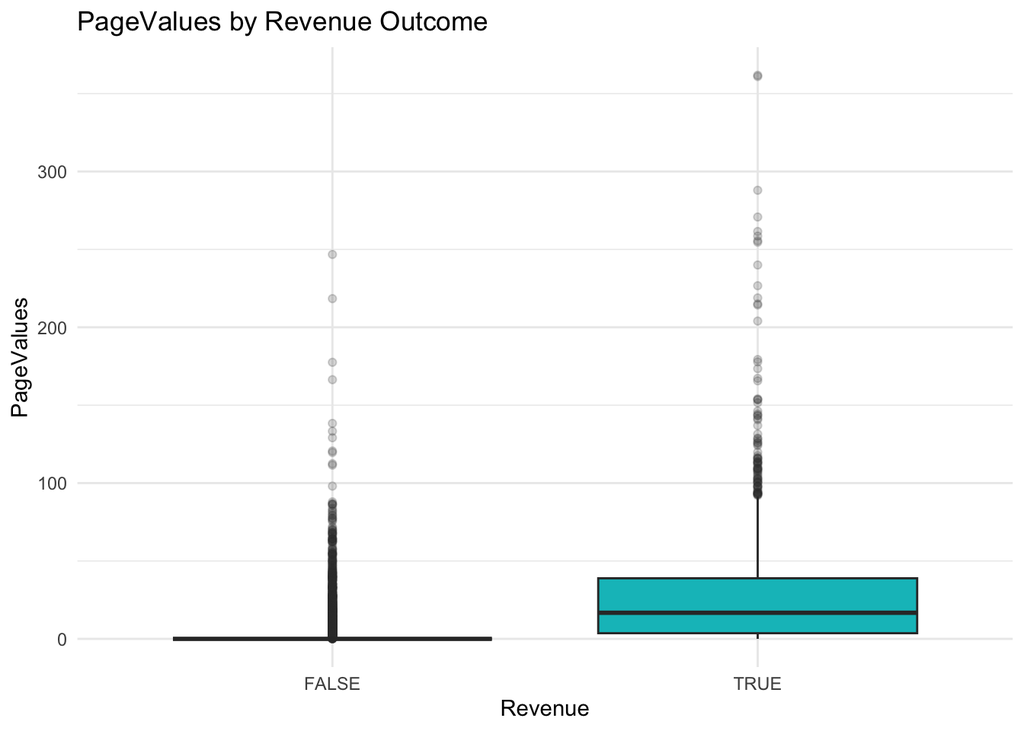

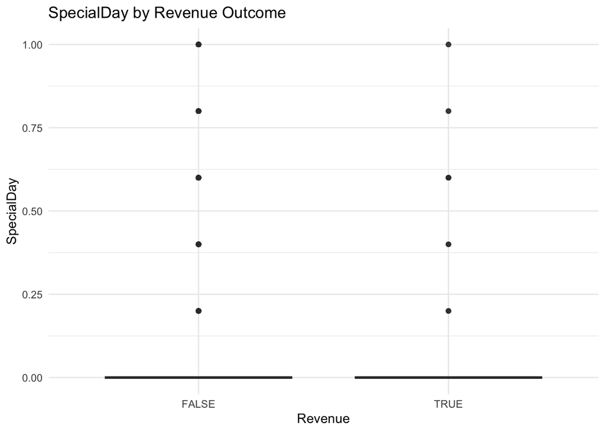

Looking at each numeric variable’s relationship with Revenue, a clear pattern emerges: converting sessions (TRUE) consistently show more engagement than non-converting sessions (FALSE), across many variables, though the strength of that separation varies.

The strongest separations:

- PageValues shows by far the clearest distinction, the FALSE group sits almost entirely at zero, while the TRUE group has a visibly elevated median and box. This is the most visually distinct relationship in the set and lines up with my expectation that PageValues would be the strongest predictor.
- ExitRates and BounceRates both show the opposite direction cleanly: FALSE sessions have a higher median and wider spread than TRUE sessions, consistent with the intuition that sessions with higher exit/bounce tendency are less likely to convert.
- ProductRelated and ProductRelated_Duration both show TRUE sessions with a modestly higher median and box than FALSE, suggesting more product browsing is associated with (though clearly not solely responsible for) conversion.
- Administrative and Administrative_Duration also show a visible shift in favor of TRUE.

Weaker but still directionally consistent:

Informational and Informational_Duration show the same pattern but more more faintly, the FALSE group is compressed almost entirely to zero, and TRUE shows only a slightly elevated box.

No meaningful separation:

- SpecialDay shows no visually distinguishable difference between FALSE and TRUE sessions, both groups are almost entirely concentrated at 0, with the handful of nonzero values scattered similarly across both outcomes and no discernible upward or downward trend from 0 through 1.0. Since this shows no relationship with the target, I will treat SpecialDay as a nominal variable rather than ordinal, and one-hot encode its six levels for logistic regression and kNN, rather than keeping it as a single ordered numeric feature that would falsely imply a smooth increasing/decreasing effect.

#### Multicollinearity Check

To check for multicollinearity among numeric variables, I will produce a correlation matrix. This is important for the logistic regression model, and done because highly correlated predictors can destabilize coefficient estimates and make them difficult to interpret. It is also relevant for kNN, though for a different reason: kNN has no coefficients to destabilize, but since it computes distance across all features equally, highly correlated variables effectively get double-counted, implicitly overweighting whatever shared signal they represent. The decision tree is the least affected by multicollinearity of the three, since it selects one variable to split on at a time and simply ignores redundant correlated variables.

```r
#Building the numeric variable set, excluding SpecialDay since it is now treated as a nominal variable
numeric_vars <- c("Administrative", "Administrative_Duration",
                   "Informational", "Informational_Duration",
                   "ProductRelated", "ProductRelated_Duration",
                   "BounceRates", "ExitRates", "PageValues")

#Corr matrix
cor_matrix <- cor(df[, numeric_vars])
round(cor_matrix, 2)
```

```
##                         Administrative Administrative_Duration Informational
## Administrative                    1.00                    0.60          0.38
## Administrative_Duration           0.60                    1.00          0.30
## Informational                     0.38                    0.30          1.00
## Informational_Duration            0.26                    0.24          0.62
## ProductRelated                    0.43                    0.29          0.37
## ProductRelated_Duration           0.37                    0.36          0.39
## BounceRates                      -0.22                   -0.14         -0.12
## ExitRates                        -0.32                   -0.21         -0.16
## PageValues                        0.10                    0.07          0.05
##                         Informational_Duration ProductRelated
## Administrative                            0.26           0.43
## Administrative_Duration                   0.24           0.29
## Informational                             0.62           0.37
## Informational_Duration                    1.00           0.28
## ProductRelated                            0.28           1.00
## ProductRelated_Duration                   0.35           0.86
## BounceRates                              -0.07          -0.20
## ExitRates                                -0.11          -0.29
## PageValues                                0.03           0.06
##                         ProductRelated_Duration BounceRates ExitRates
## Administrative                             0.37       -0.22     -0.32
## Administrative_Duration                    0.36       -0.14     -0.21
## Informational                              0.39       -0.12     -0.16
## Informational_Duration                     0.35       -0.07     -0.11
## ProductRelated                             0.86       -0.20     -0.29
## ProductRelated_Duration                    1.00       -0.18     -0.25
## BounceRates                               -0.18        1.00      0.91
## ExitRates                                 -0.25        0.91      1.00
## PageValues                                 0.05       -0.12     -0.17
##                         PageValues
## Administrative                0.10
## Administrative_Duration       0.07
## Informational                 0.05
## Informational_Duration        0.03
## ProductRelated                0.06
## ProductRelated_Duration       0.05
## BounceRates                  -0.12
## ExitRates                    -0.17
## PageValues                    1.00
```

Using a threshold of |r| > 0.7, two pairs of predictors show elevated correlation: ProductRelated and ProductRelated_Duration (r = 0.86), and BounceRates and ExitRates (r = 0.91). Both pairings make intuitive sense, a session with more product-related page views would naturally accumulate more total time on those pages, and bounce rate and exit rate are closely related metrics of session disengagement, so a strong relationship between them isn’t surprising.

A handful of other pairs show moderate correlation worth noting but well below the 0.7 threshold: Administrative and Administrative_Duration (r = 0.60), and Informational and Informational_Duration (r = 0.62)- the same page-count-to-duration pattern as ProductRelated, just weaker. BounceRates and ExitRates both also show a consistent negative relationship with PageValues and the page-count/duration variables, which aligns with the earlier boxplot findings that higher bounce/exit rates are associated with lower conversion.

Rather than simply dropping one variable from each pair, I will address this multicollinearity through feature engineering, creating new derived features that capture the shared signal in each pair as a single variable rather than discarding information outright.

For ProductRelated and ProductRelated_Duration, I will engineer an average time per product page feature (ProductRelated_Duration divided by ProductRelated, with zero-page sessions set to zero), which captures engagement intensity rather than raw count or raw time alone. For BounceRates and ExitRates, I will engineer a combined disengagement score, computed as the average of the two rates.

These derived features will replace their source variables for logistic regression and kNN, removing the correlated pairs while preserving the signal they carried. Including both highly correlated variables in either pair would otherwise risk unstable coefficients for logistic regression or overweighted distance contributions for kNN. The decision tree will retain all original variables as-is, since it selects one variable to split on at a time and is not similarly affected by this redundancy.

#### Nominal Variable Distributions

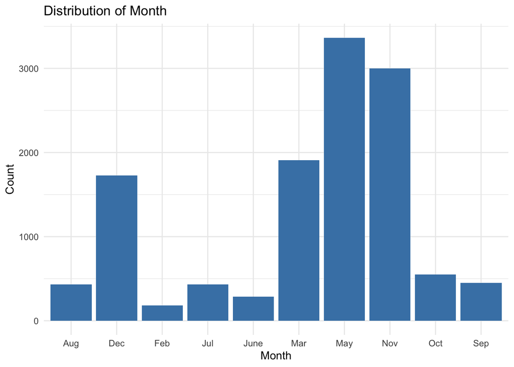

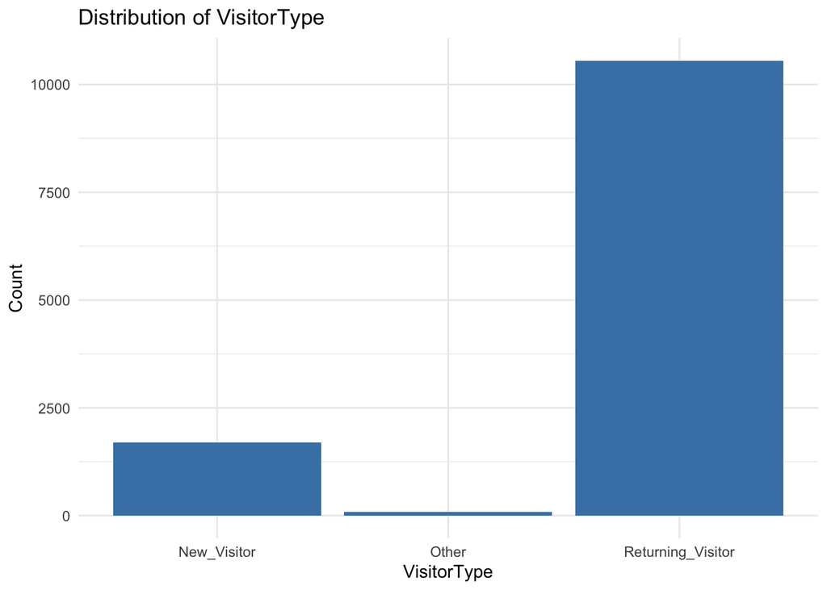

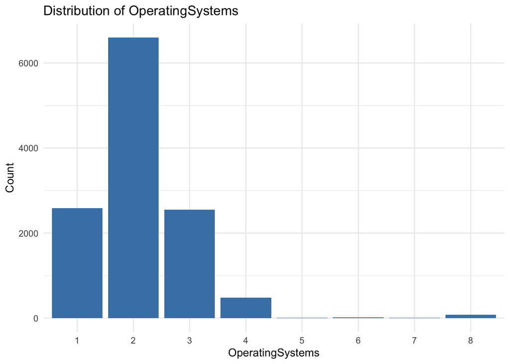

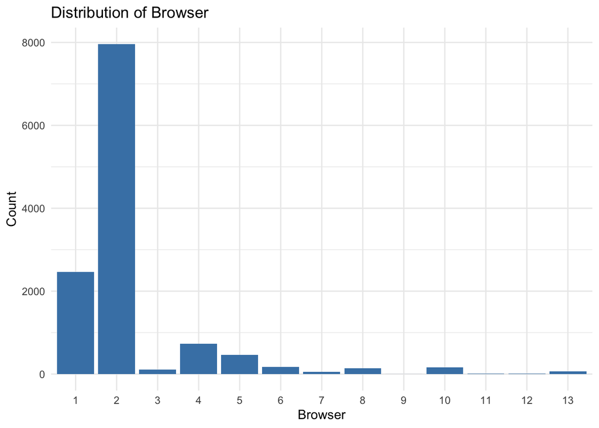

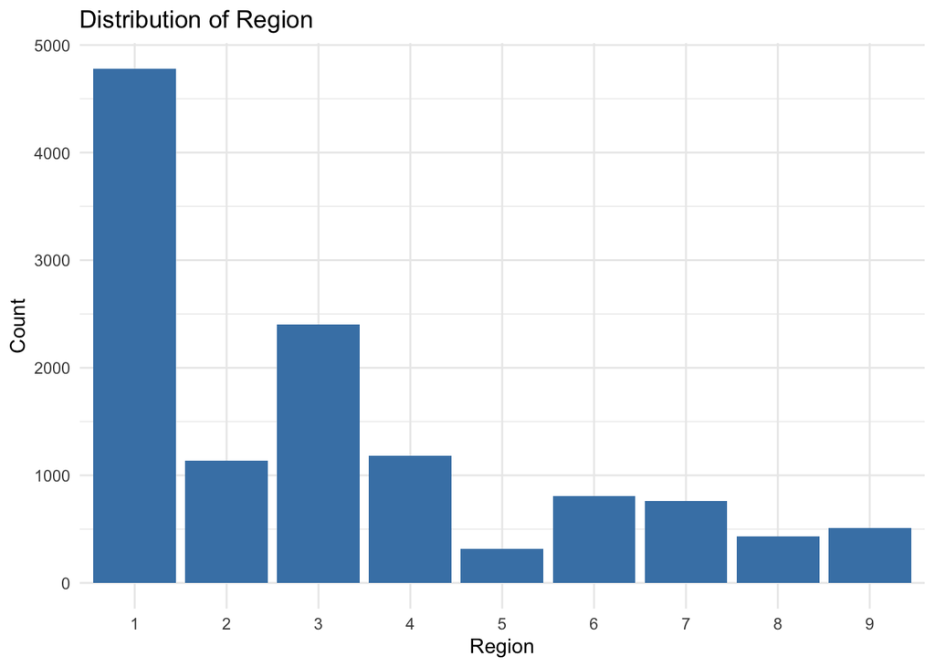

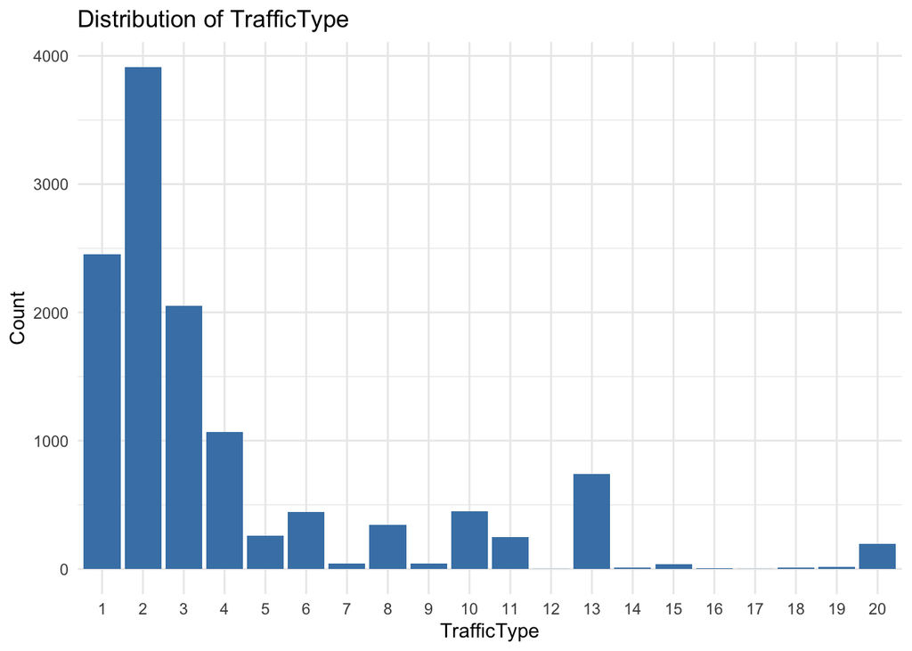

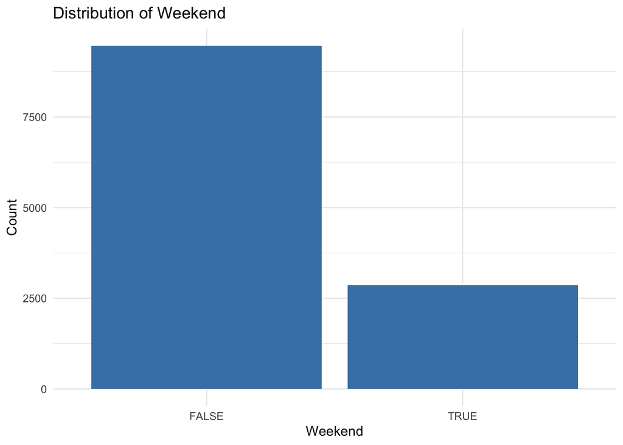

Across the nominal variables, several show imbalanced distributions rather than an even spread across categories, which reinforces the sparse-category-grouping decision made earlier.

#### Nominal Variable Relationship with Target

I will now plot each nominal variable’s relationship to the target and run a chi-squared test on each nominal variable. This sees whether there is a statistically significant association between each categorical feature and the likelihood of a purchase, rather than relying on visual impressions of the proportional bar charts alone.

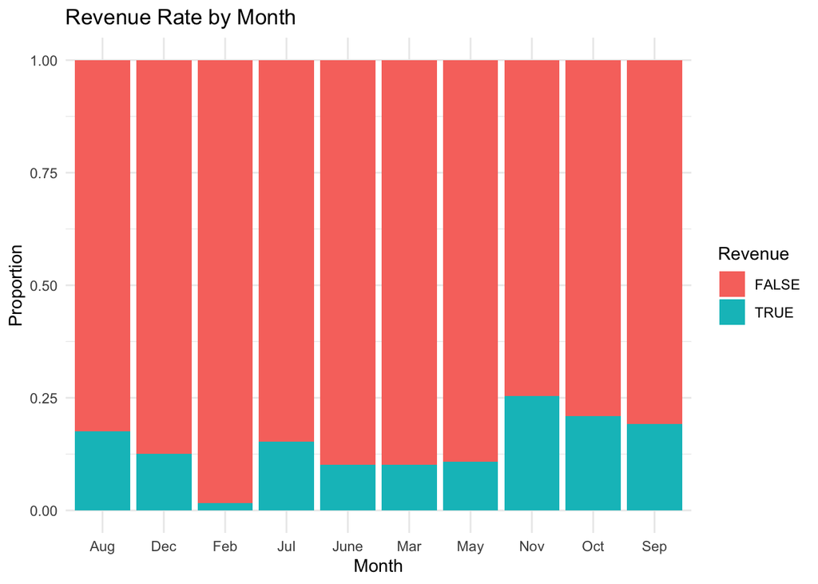

```
##
##  Pearson's Chi-squared test
##
## data:  table(df$Month, df$Revenue)
## X-squared = 384.93, df = 9, p-value < 2.2e-16
```

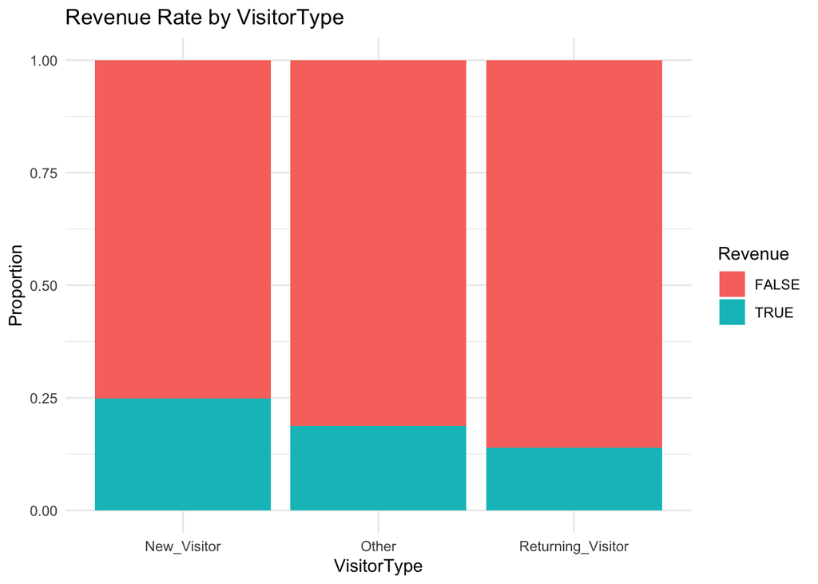

```
##
##  Pearson's Chi-squared test
##
## data:  table(df$VisitorType, df$Revenue)
## X-squared = 135.25, df = 2, p-value < 2.2e-16
```

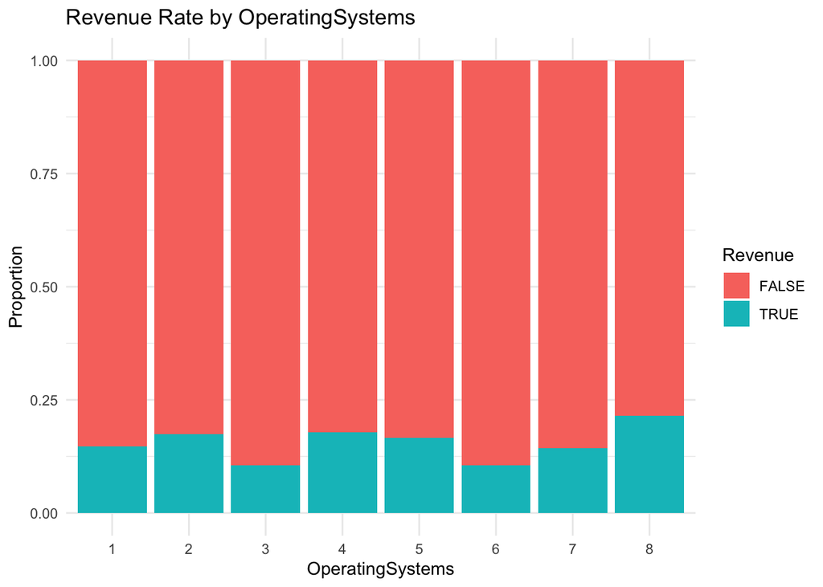

```
##
##  Pearson's Chi-squared test
##
## data:  table(df$OperatingSystems, df$Revenue)
## X-squared = 75.027, df = 7, p-value = 1.416e-13
```

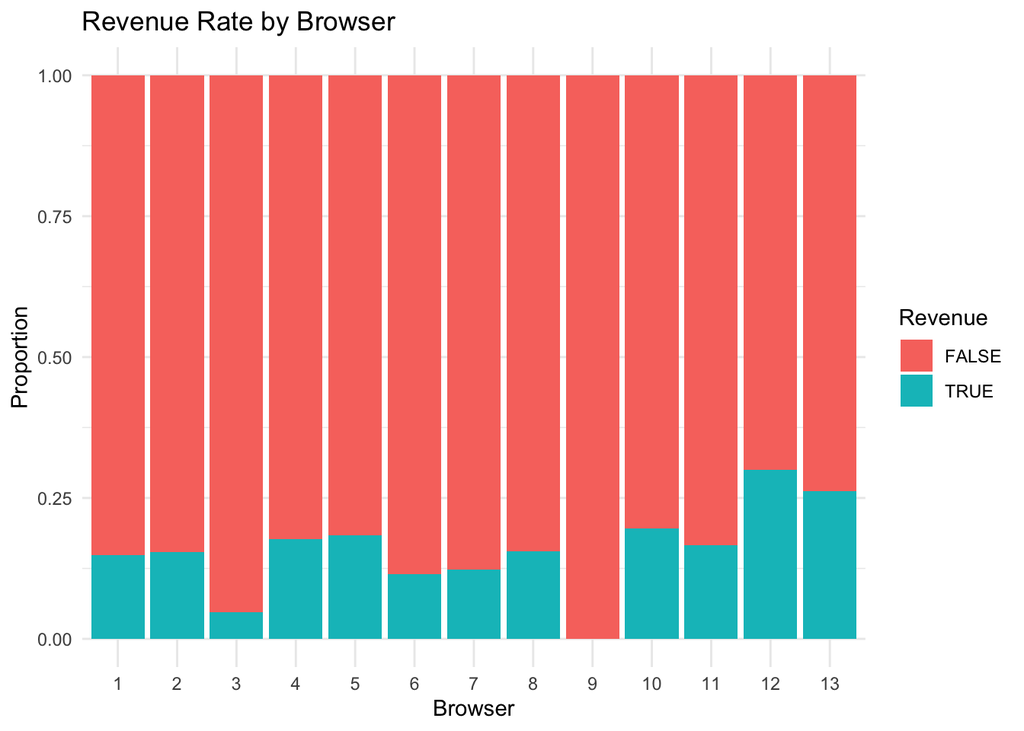

```
##
##  Pearson's Chi-squared test
##
## data:  table(df$Browser, df$Revenue)
## X-squared = 27.715, df = 12, p-value = 0.006088
```